# Group Membership

Last updated: 2019-04-22

## MANOVA vs DFA & Logistic Regression

MANOVA and Hotelling’s *T*<sup>2</sup>: *p* Continuous ~ *q* Categorical

MANOVA creates a composite variable from the set of outcome variables and asks whether the groups differ.

- Predict the composite from the group membership

DFA and Logistic Regression create a composite variable from the set of predictor variables and asks which variables best predict group membership.

- Predict group membership from the composite scores

## Tibetan skulls

```r
M <- read_excel("../data/Tibetan_Skulls.xlsx")
str(M)
```

```
## Classes 'tbl_df', 'tbl' and 'data.frame':    32 obs. of  6 variables:
##  $ Skull_Length: num  190 172 167 170 175 ...
##  $ Skull_Width : num  152 132 130 150 138 ...
##  $ Skull_Height: num  145 126 126 134 126 ...
##  $ Face_Height : num  73.5 63 69.5 64.5 77.5 71.5 70.5 73.5 70 62 ...
##  $ Face_Breadth: num  136 121 120 128 136 ...
##  $ Origin      : chr  "Sikkim" "Sikkim" "Sikkim" "Sikkim" ...
```

```r
M <- M %>% mutate(Origin = factor(Origin))
```

## Tibetan skulls

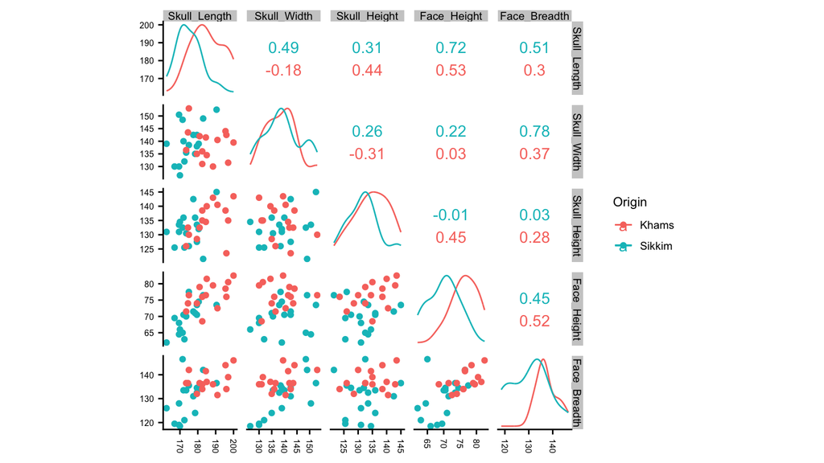

## Tibetan skulls

```r
fm <- glm(Origin ~ ., data = M, family = "binomial")
```

- Use `~ .` to include all other variables

## Tibetan skulls

```
##
## Call:
## glm(formula = Origin ~ ., family = "binomial", data = M)
##
## Deviance Residuals:
##      Min        1Q    Median        3Q       Max
## -1.61850  -0.36347   0.00947   0.44172   1.55552
##
## Coefficients:
##              Estimate Std. Error z value Pr(>|z|)
## (Intercept)  73.51908   44.81155   1.641   0.1009
## Skull_Length -0.12895    0.09688  -1.331   0.1832
## Skull_Width   0.32337    0.18138   1.783   0.0746 .
## Skull_Height -0.10429    0.12311  -0.847   0.3969
## Face_Height  -0.33545    0.23132  -1.450   0.1470
## Face_Breadth -0.42403    0.27276  -1.555   0.1200
## ---
## Signif. codes:  0 '***' 0.001 '**' 0.01 '*' 0.05 '.' 0.1 ' ' 1
##
## (Dispersion parameter for binomial family taken to be 1)
##
##     Null deviance: 44.236  on 31  degrees of freedom
## Residual deviance: 20.162  on 26  degrees of freedom
## AIC: 32.162
##
## Number of Fisher Scoring iterations: 7
```

## Tibetan skulls

```r
Anova(fm, type = "III")
```

```
## Analysis of Deviance Table (Type III tests)
##
## Response: Origin
##              LR Chisq Df Pr(>Chisq)
## Skull_Length   2.0626  1    0.15095
## Skull_Width    5.9786  1    0.01448 *
## Skull_Height   0.7866  1    0.37512
## Face_Height    2.9075  1    0.08817 .
## Face_Breadth   4.9508  1    0.02608 *
## ---
## Signif. codes:  0 '***' 0.001 '**' 0.01 '*' 0.05 '.' 0.1 ' ' 1
```

## Tibetan skulls

```r
logistic.display(fm)
```

```
##
## Logistic regression predicting Origin : Sikkim vs Khams
##
##                           crude OR(95%CI)   adj. OR(95%CI)
## Skull_Length (cont. var.) 0.83 (0.72,0.95)  0.88 (0.73,1.06)
##
## Skull_Width (cont. var.)  1.01 (0.91,1.12)  1.38 (0.97,1.97)
##
## Skull_Height (cont. var.) 0.92 (0.82,1.04)  0.9 (0.71,1.15)
##
## Face_Height (cont. var.)  0.68 (0.53,0.89)  0.72 (0.45,1.13)
##
## Face_Breadth (cont. var.) 0.83 (0.71,0.97)  0.65 (0.38,1.12)
##
##                           P(Wald's test) P(LR-test)
## Skull_Length (cont. var.) 0.183          0.151
##
## Skull_Width (cont. var.)  0.075          0.014
##
## Skull_Height (cont. var.) 0.397          0.375
##
## Face_Height (cont. var.)  0.147          0.088
##
## Face_Breadth (cont. var.) 0.12           0.026
##
## Log-likelihood = -10.081
## No. of observations = 32
## AIC value = 32.162
```

## Logistic regression vs. DFA

Both:

- Which variable(s) are good predictors of group membership
- Groups are known *a priori*
- Uses linear combinations of variables
- **Predict new observations**

Differences:

- Some assumptions
- Predictive ability (depends on specifics)
- See: [this stackexchange](https://stats.stackexchange.com/questions/95247/logistic-regression-vs-lda-as-two-class-classifiers)
- Ease of interpretation for different questions

## Iris data

```r
glimpse(iris)
```

```
## Observations: 150
## Variables: 5
## $ Sepal.Length <dbl> 5.1, 4.9, 4.7, 4.6, 5.0, 5.4, 4.6, 5.0, 4.4, 4.9, 5…
## $ Sepal.Width  <dbl> 3.5, 3.0, 3.2, 3.1, 3.6, 3.9, 3.4, 3.4, 2.9, 3.1, 3…
## $ Petal.Length <dbl> 1.4, 1.4, 1.3, 1.5, 1.4, 1.7, 1.4, 1.5, 1.4, 1.5, 1…
## $ Petal.Width  <dbl> 0.2, 0.2, 0.2, 0.2, 0.2, 0.4, 0.3, 0.2, 0.2, 0.1, 0…
## $ Species      <fct> setosa, setosa, setosa, setosa, setosa, setosa, set…
```

## Iris data

Anderson, E. 1935. The irises of the Gaspe Peninsula. *Bulletin of the American Iris Society* 59: 2–5.

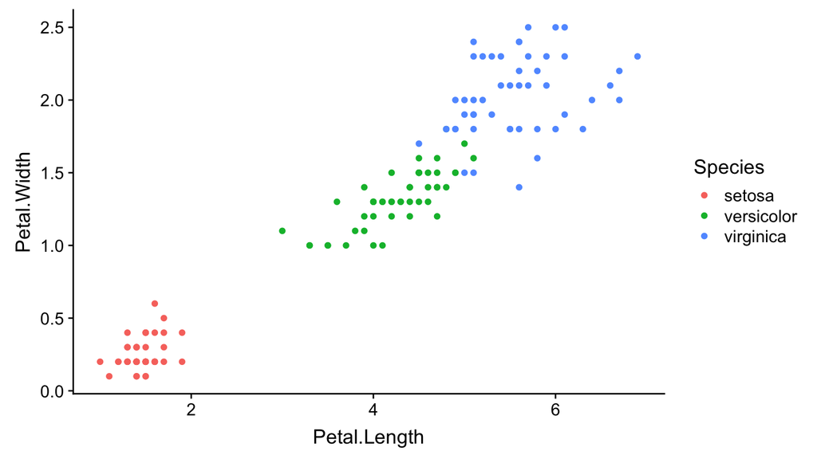

## Iris data

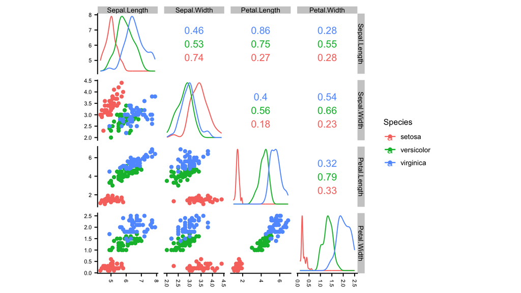

## DFA in R

Linear discriminant analysis:

- `lda()` with `Group ~ Predictors`

```r
iris.lda <- lda(Species ~ . ,  data = iris)
```

## Posterior prediction

```r
iris.predict <- predict(iris.lda, iris[, 1:4])
iris.predict$posterior
```

```
##           setosa   versicolor    virginica
## 1   1.000000e+00 3.896358e-22 2.611168e-42
## 2   1.000000e+00 7.217970e-18 5.042143e-37
## 3   1.000000e+00 1.463849e-19 4.675932e-39
## 4   1.000000e+00 1.268536e-16 3.566610e-35
## 5   1.000000e+00 1.637387e-22 1.082605e-42
## 6   1.000000e+00 3.883282e-21 4.566540e-40
## 7   1.000000e+00 1.113469e-18 2.302608e-37
## 8   1.000000e+00 3.877586e-20 1.074496e-39
## 9   1.000000e+00 1.902813e-15 9.482936e-34
## 10  1.000000e+00 1.111803e-18 2.724060e-38
## 11  1.000000e+00 1.185277e-23 3.237084e-44
## 12  1.000000e+00 1.621649e-18 1.833201e-37
## 13  1.000000e+00 1.459225e-18 3.262506e-38
## 14  1.000000e+00 1.117219e-19 1.316642e-39
```

[output cut: 136 more lines]

## Classification

```r
(iris.classify <- iris.predict$class)
```

```
##   [1] setosa     setosa     setosa     setosa     setosa     setosa
##   [7] setosa     setosa     setosa     setosa     setosa     setosa
##  [13] setosa     setosa     setosa     setosa     setosa     setosa
##  [19] setosa     setosa     setosa     setosa     setosa     setosa
##  [25] setosa     setosa     setosa     setosa     setosa     setosa
##  [31] setosa     setosa     setosa     setosa     setosa     setosa
##  [37] setosa     setosa     setosa     setosa     setosa     setosa
##  [43] setosa     setosa     setosa     setosa     setosa     setosa
##  [49] setosa     setosa     versicolor versicolor versicolor versicolor
##  [55] versicolor versicolor versicolor versicolor versicolor versicolor
##  [61] versicolor versicolor versicolor versicolor versicolor versicolor
##  [67] versicolor versicolor versicolor versicolor virginica  versicolor
##  [73] versicolor versicolor versicolor versicolor versicolor versicolor
##  [79] versicolor versicolor versicolor versicolor versicolor virginica
##  [85] versicolor versicolor versicolor versicolor versicolor versicolor
##  [91] versicolor versicolor versicolor versicolor versicolor versicolor
##  [97] versicolor versicolor versicolor versicolor virginica  virginica
## [103] virginica  virginica  virginica  virginica  virginica  virginica
## [109] virginica  virginica  virginica  virginica  virginica  virginica
## [115] virginica  virginica  virginica  virginica  virginica  virginica
## [121] virginica  virginica  virginica  virginica  virginica  virginica
## [127] virginica  virginica  virginica  virginica  virginica  virginica
## [133] virginica  versicolor virginica  virginica  virginica  virginica
## [139] virginica  virginica  virginica  virginica  virginica  virginica
## [145] virginica  virginica  virginica  virginica  virginica  virginica
## Levels: setosa versicolor virginica
```

## Percent correct

Mean value of the correct classifications

```r
mean(iris.classify == iris$Species)
```

```
## [1] 0.98
```

## Confusion matrix

```r
table(Original = iris$Species, Predicted = iris.classify)
```

```
##             Predicted
## Original     setosa versicolor virginica
##   setosa         50          0         0
##   versicolor      0         48         2
##   virginica       0          1        49
```

## Predicting a new observation

```r
new_iris <- data.frame(Sepal.Length = c(6.11),
                       Sepal.Width = c(3.55),
                       Petal.Length = c(4.44),
                       Petal.Width = c(2.5))
```

## Predicting a new observation

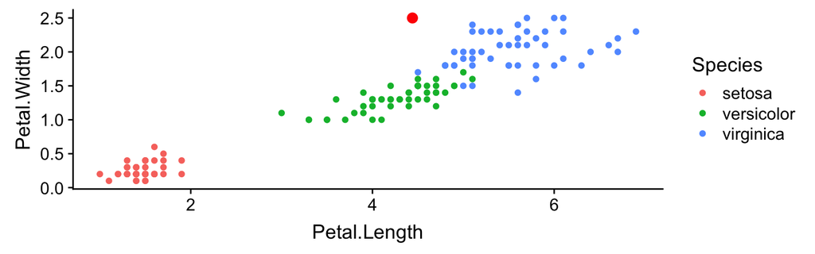

```r
predict(iris.lda, new_iris)
```

```
## $class
## [1] virginica
## Levels: setosa versicolor virginica
##
## $posterior
##         setosa  versicolor virginica
## 1 7.959959e-31 0.001175921 0.9988241
##
## $x
##         LD1      LD2
## 1 -4.179547 4.130081
```

## Predicting a new observation

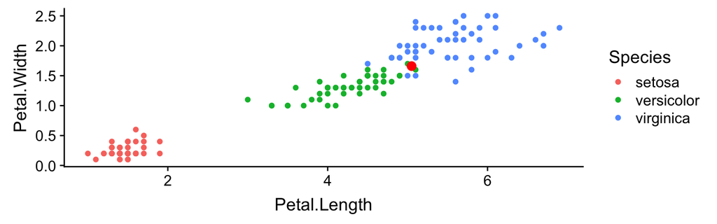

```r
predict(iris.lda, new_iris)
```

[output not shown]

## Tibetan skulls

```r
M <- read_excel("../data/Tibetan_Skulls.xlsx") %>%
  mutate(Origin = factor(Origin)) %>%
  as.data.frame()
str(M)
```

```
## 'data.frame':    32 obs. of  6 variables:
##  $ Skull_Length: num  190 172 167 170 175 ...
##  $ Skull_Width : num  152 132 130 150 138 ...
##  $ Skull_Height: num  145 126 126 134 126 ...
##  $ Face_Height : num  73.5 63 69.5 64.5 77.5 71.5 70.5 73.5 70 62 ...
##  $ Face_Breadth: num  136 121 120 128 136 ...
##  $ Origin      : Factor w/ 2 levels "Khams","Sikkim": 2 2 2 2 2 2 2 2 2 2 ...
```

```r
skulls_lda <- lda(Origin ~ ., data = M)
```

## Tibetan skulls

```r
skulls_predict <- predict(skulls_lda, M[, 1:5])
(skulls_classify <- skulls_predict$class)
```

```
##  [1] Sikkim Sikkim Sikkim Sikkim Khams  Sikkim Sikkim Sikkim Sikkim Sikkim
## [11] Sikkim Sikkim Khams  Khams  Sikkim Sikkim Sikkim Khams  Khams  Khams
## [21] Khams  Khams  Sikkim Khams  Sikkim Khams  Khams  Khams  Sikkim Khams
## [31] Khams  Khams
## Levels: Khams Sikkim
```

## Tibetan skulls

```r
mean(skulls_classify == M$Origin)
```

```
## [1] 0.8125
```

```r
table(Original = M$Origin, Predicted = skulls_classify)
```

```
##         Predicted
## Original Khams Sikkim
##   Khams     12      3
##   Sikkim     3     14
```

## Oreodonts

Skull measurements of oreodonts

[figure not shown]

## Oreodonts

```r
M <- read_excel("../data/Oreodont.xlsx") %>%
  mutate(Sex = factor(Sex)) %>%
  as.data.frame()
```

## Oreodonts

```r
M %>% group_by(Sex) %>% summarise_each("mean")
```

```
## # A tibble: 2 x 3
##   Sex   Length Width
##   <fct>  <dbl> <dbl>
## 1 F       22    13.5
## 2 M       29.3  17.3
```

## Oreodonts

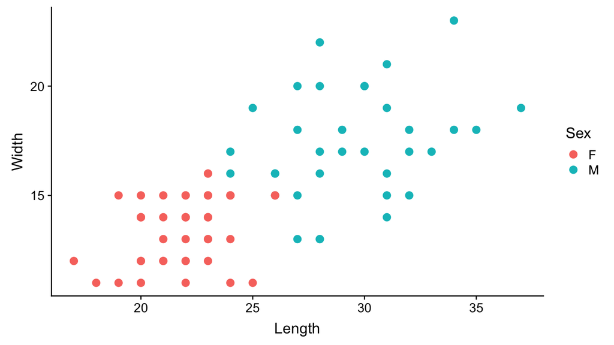

## Oreodonts

```r
oreo_lda <- lda(Sex ~ ., data = M)
oreo_predict <- predict(oreo_lda, M[, 1:2])
(oreo_classify <- oreo_predict$class)
```

```
##  [1] M M M M M M M M M M M M M M M M M M M M F M M M M M F M M F M M M M F
## [36] F F F F F F F F F F F F F F F F F F F F F F F F F F F F F F F F F F F
## [71] F F F F F F F F F F F
## Levels: F M
```

## Oreodonts

```r
mean(oreo_classify == M$Sex)
```

```
## [1] 0.9506173
```

```r
table(Original = M$Sex, Predicted = oreo_classify)
```

```
##         Predicted
## Original  F  M
##        F 46  0
##        M  4 31
```

## Predict sex of new oreodonts

```r
new_oreo <- data.frame(Length = c(30, 25, 25),
                       Width = c(15, 20, 15))
predict(oreo_lda, new_oreo)
```

```
## $class
## [1] M M F
## Levels: F M
##
## $posterior
##            F         M
## 1 0.01998277 0.9800172
## 2 0.16356478 0.8364352
## 3 0.75820871 0.2417913
##
## $x
##           LD1
## 1  1.56706914
## 2  0.82963240
## 3 -0.07548666
```

## Prediction with `glm()`

```r
logit_to_prob <- function(logit) {
  odds <- exp(logit)
  prob <- odds / (1 + odds)
  return(prob)
}

fm <- glm(Sex ~ ., data = M, family = "binomial")
```

## Prediction with `glm()`

```r
(pred <- predict(fm, newdata = new_oreo))
```

```
##          1          2          3
##  9.2935302  7.6636205 -0.5391932
```

```r
logit_to_prob(pred)
```

```
##         1         2         3
## 0.9999080 0.9995306 0.3683753
```

## Quiz 13-3

No more lectures this week.